# Kickoff - lecture 8

Peter Ganong and Maggie Shi

## Lab assessment debrief from TAs

- Q1: adding code documentation
  - Vague explanations on description of data cleaning steps or graph description
  - Be as specific as possible!
- Q2: code summary and aesthetic changes
  - To get full credit, we were looking for code *and* description in plain English of change

## Lab assessment debrief from TAs

- Q3: content-related improvements.
  - *“Recall that your goal is to help the Department of Finance decide how to schedule their enforcement officer shifts throughout the week.”*
- Strong answers:
  - Flagged issues with using year-to-year variation
  - Pointed out incompleteness of 2018
  - Suggested slicing by geography or violation type
  - Noted that plotting total ticket counts can be misleading, suggested normalizing

## Midcourse survey

- Where we are in the course (review [syllabus](https://docs.google.com/document/d/1NCOS61C5babMWy0JaMvSn89iKRVBYATyD_UoKRz3ljk/edit?tab=t.0))
- Grading has been slow, working hard to speed it up behind the scenes
- Upload/printing process (normal week)
  - Monday/Wednesday before class: push PDF and print
  - After: fix typos or things that are unclear

## Midcourse survey cont’d

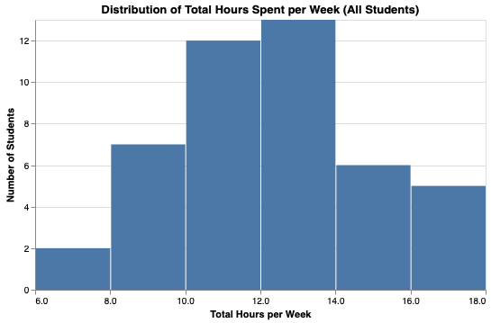

## Exporting png vs. svg

- To improve resolution of `altair` charts, you can export the chart as a `png` or `svg`. Instructions [here](https://github.com/uchicago-harris-dap/student30538-w26/wiki/Solution---Wrapping-Code-Output-and-Knitting-to-PDF)
- **PNG (raster image)** — fixed resolution. Enlarging causes blur. Best for maximum cross-platform reliability and printing.
- **SVG (vector image)** — geometric primitives. Ideal for digital-first platforms (`.html`)

## png

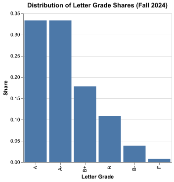

## svg

[figure not shown]

## Final project repository example

- Discussed in lab this week
- [Link here](https://github.com/uchicago-harris-dap/final_project_template_w26) and also Canvas front page